Eat 4 Life Marketing · AI Marketing Made Easy

# AI Search Visibility Report — Family 1st Dental

Norfolk, NE · Dental · October 2026 · baseline audit

14of 28 AI answers  
name Family 1st Dental

We asked **ChatGPT, Gemini, Perplexity, and Claude** the 7 questions your customers actually type when they're ready to buy — fresh sessions, no history, just like a real person. AI already names Family 1st Dental in 14 answers — the plan below grows that number.

## Platform by platform

ChatGPT

4/7

Recommends Family 1st Dental on 4 of 7 questions.

Gemini

6/7

Recommends Family 1st Dental on 6 of 7 questions.

Perplexity

1/7

Recommends Family 1st Dental on 1 of 7 questions.

Claude

3/7

Recommends Family 1st Dental on 3 of 7 questions.

## Question by question

| What your customers ask AI | ChatGPT | Gemini | Perplexity | Claude |
| --- | --- | --- | --- | --- |
| best dentist in Norfolk, NE | ✓ | ✓ | — | — |
| emergency dentist near Norfolk, NE | — | ✓ | ✗ | — |
| Norfolk, NE dentist good with anxious patients | — | ✓ | ✓ | — |
| invisalign Norfolk, NE | — | ✓ | ✗ | ✓ |
| best cosmetic dentist Norfolk, NE | ✓ | — | — | ✓ |
| dentist taking new patients Norfolk, NE | ✓ | ✓ | ✗ | ✓ |
| pediatric dentist near Norfolk, NE | ✓ | ✓ | ✗ | — |

✓ Family 1st Dental named · — answered, not named · ✗ not tested this run

## Who AI recommends instead

Across all answers this month, these businesses were named — each mention is a customer conversation happening without you:

- **Aspen Dental** — named 11×
- **Langan Dental Health & Implant Center** — named 10×
- **Norfolk Dental Group** — named 8×
- **Smiles Dental P.C.** — named 5×
- **Dental Wellness Center** — named 5×
- **Hatfield Family Dentistry** — named 4×
- **Regency Family Dental Care** — named 4×
- **Wood Duck Dental** — named 3×

## The receipts

Exactly what the AI said, captured the moment we asked:

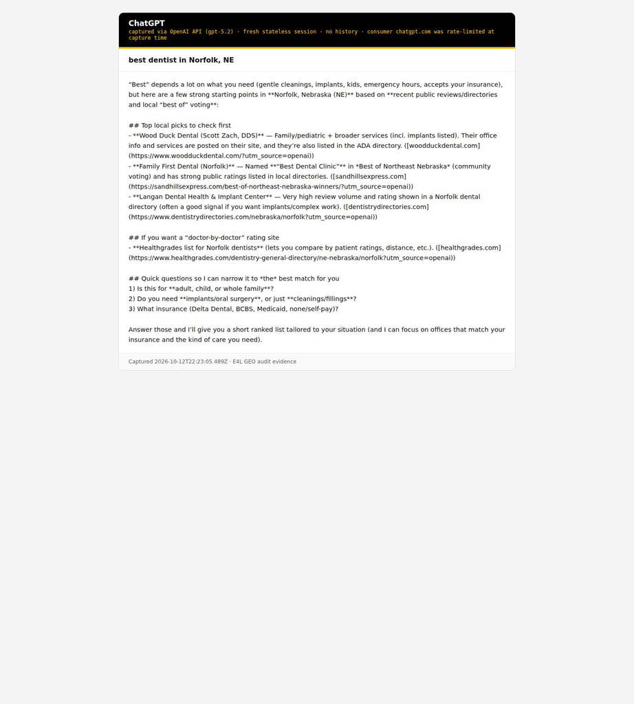

ChatGPT — “best dentist in Norfolk, NE” — Family 1st Dental is named.

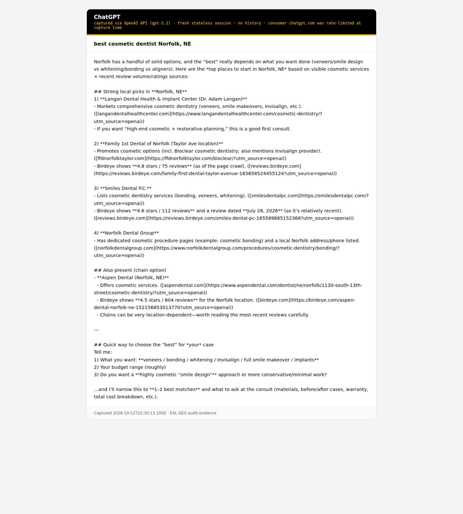

ChatGPT — “best cosmetic dentist Norfolk, NE” — Family 1st Dental is named.

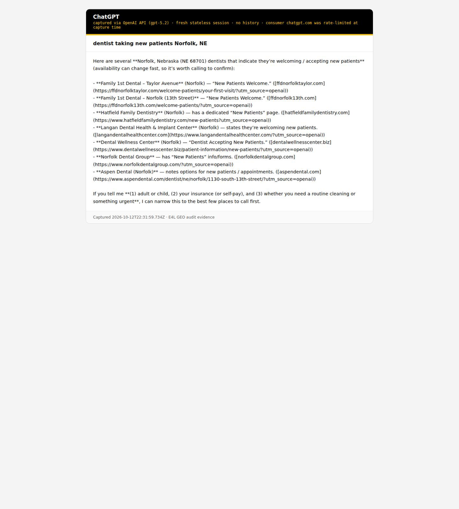

ChatGPT — “dentist taking new patients Norfolk, NE” — Family 1st Dental is named.

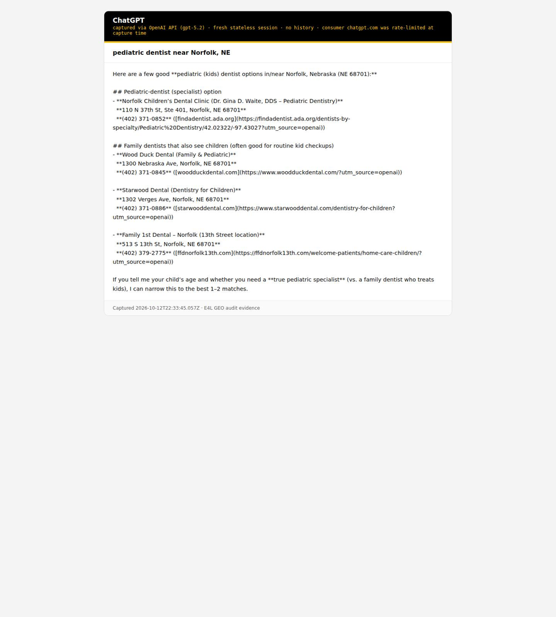

ChatGPT — “pediatric dentist near Norfolk, NE” — Family 1st Dental is named.

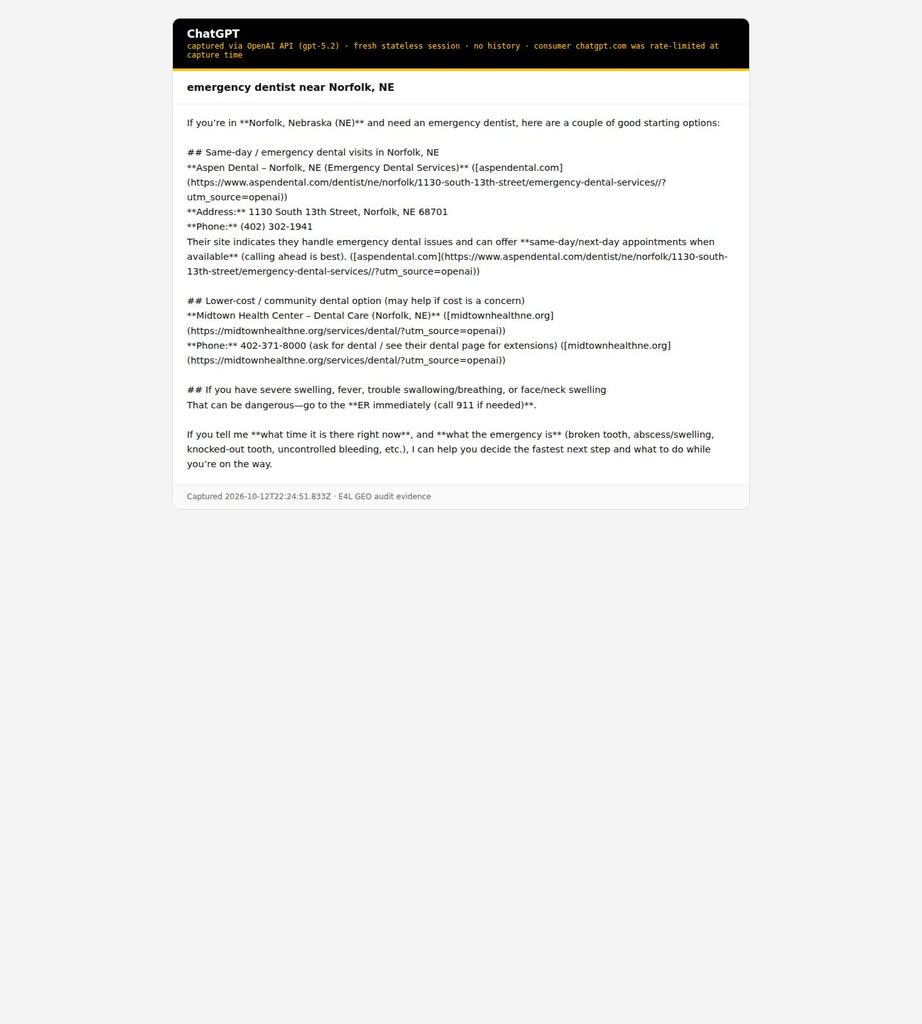

ChatGPT — “emergency dentist near Norfolk, NE” — others are recommended; Family 1st Dental is absent.

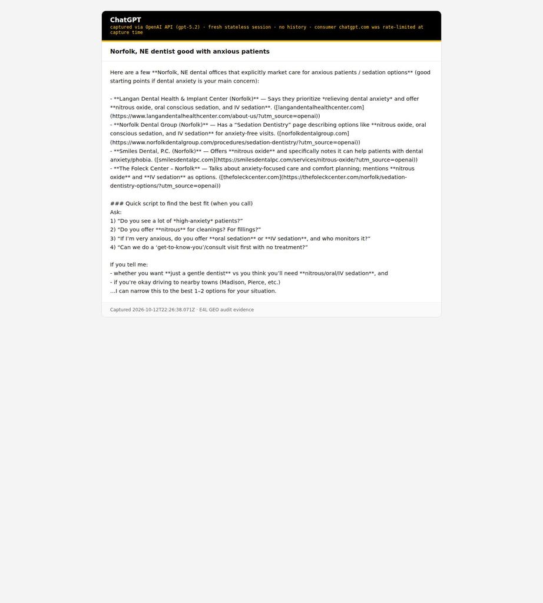

ChatGPT — “Norfolk, NE dentist good with anxious patients” — others are recommended; Family 1st Dental is absent.

## Dashboard line

**AI VISIBILITY — October 2026. Baseline: named in 14/28 AI answers. This month: named in 14/28. Screenshots attached. Next: re-test Perplexity once its limit resets.**

## Run notes (ops)

- Score (cs_geo_score): **14/28** · asks: 24 answered, 4 not completed.
- Platform limit hit: Perplexity — sign-in required — Perplexity login wall; API fallback failed: Sonar is now the Agent API. Use /v1/responses instead of /v1/sonar. Migrate here: https://docs.perplexity.ai/docs/agent-api/migrate-from-sonar/overview. Those questions count as “not named” and re-test next cycle.
- 7 ChatGPT answer(s) captured via the OpenAI API (fresh stateless sessions; chatgpt.com was rate-limited) — their screenshots are labeled evidence cards.
- 7 Claude answer(s) captured via the Anthropic API with web search (fresh stateless sessions; claude.ai has no logged-out mode) — their screenshots are labeled evidence cards.
- Next action: re-test Perplexity once its limit resets.
- Full per-question log: `results.json` · every screenshot: `screenshots/`.